# GroupC_HW4

2023-12-22

# FSDS - Chapter 4

## Exercise 4.24

Refer to the vegetarian survey result in Exercise 4.6, with $n = 25$ and no vegetarians. (a) Find the Bayesian estimate of π using a beta prior distribution with $\alpha = \beta$ equal (i) 0.5, (ii) 1.0, (iii) 10.0. Explain how the choice of prior distribution affects the posterior mean estimate. (b) If you were planning how to take a larger survey from the same population, explain how you can use the posterior results of the previous survey with $n = 25$ based on the prior with $\alpha = \beta = 1$ to form the prior distribution to use with the new survey results.

**Solution**

```r
n = 25
vegetarian = rep(0, n)
```

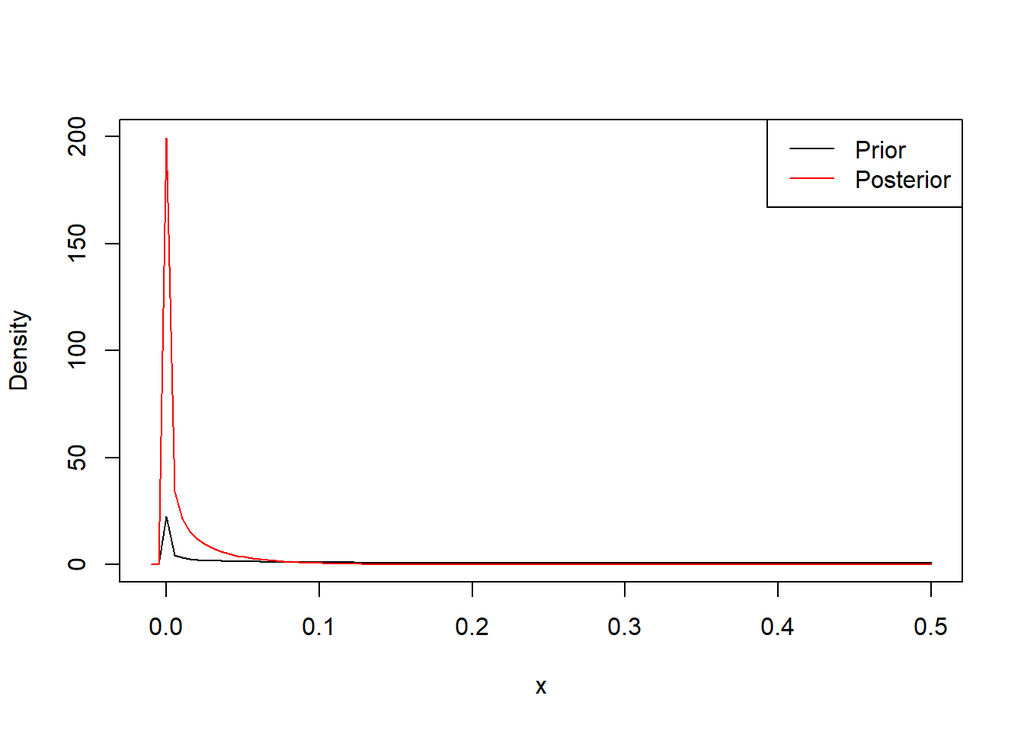

```r
alpha <- beta <- 0.5
curve(dbeta(x, alpha, beta), ylab="Density", xlim=c(-0.01,0.5), ylim=c(0, 200))
curve(dbeta(x, alpha + sum(vegetarian), beta + n - sum(vegetarian)), add=TRUE, col="red")
legend("topright", legend=c("Prior", "Posterior"), col=c("black", "red"), lty=1)
```

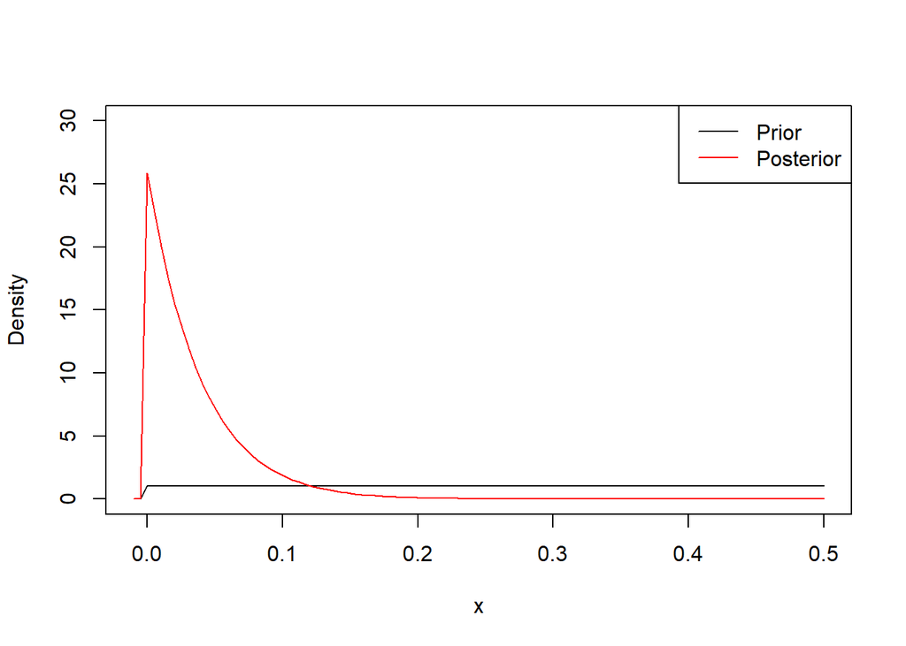

```r
alpha <- beta <- 1
curve(dbeta(x, alpha, beta), ylab="Density", xlim=c(-0.01,0.5), ylim=c(0, 30))
curve(dbeta(x, alpha + sum(vegetarian), beta + n - sum(vegetarian)), add=TRUE, col="red")
legend("topright", legend=c("Prior", "Posterior"), col=c("black", "red"), lty=1)
```

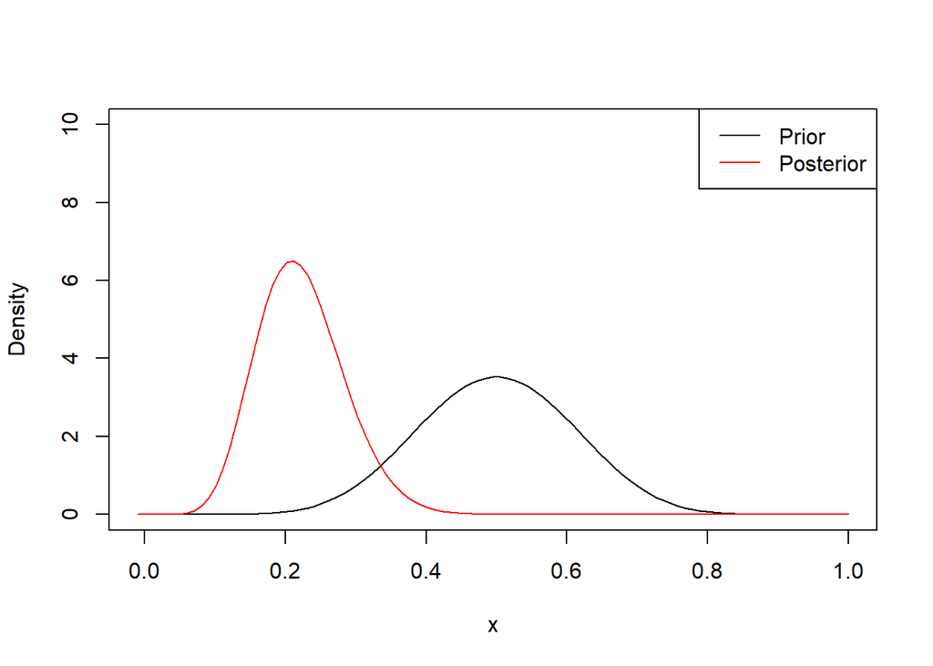

```r
alpha <- beta <- 10
curve(dbeta(x, alpha, beta), ylab="Density", xlim=c(-0.01,1), ylim=c(0, 10))
curve(dbeta(x, alpha + sum(vegetarian), beta + n - sum(vegetarian)), add=TRUE, col="red")
legend("topright", legend=c("Prior", "Posterior"), col=c("black", "red"), lty=1)
```

The posterior mean will approach the prior mean, so using the value 0.5 and 1 the mean will be near to zero and, using the value 10, the posterior mean will be between zero and the prior mean. We can notice that the posterior mean is 0.2 so the data mean weights more than the prior mean.

```r
x <- seq(0, 1, 100)
values <- dbeta(x, 1 + sum(vegetarian), 1 + n - sum(vegetarian))
maximum <- max(values)
p <- x[values == maximum] # Equal to zero

# Always zero
new <- rbinom(10, 1, p)
new
```

```
##  [1] 0 0 0 0 0 0 0 0 0 0
```

## Exercise 4.62

For the bootstrap method, explain the similarity and difference between the true sampling distribution of $\hat{\theta}$ and the empirically-generated bootstrap distribution in terms of its center and its spread.

**Solution**

The true sampling distribution is the distribution of the statistic obtained if we infinitely sample from the population. The bootstrap distribution is the distribution of the statistic obtained if we sample from the dataset. For the CLT the centers of both the distributions will be similar, but the spread of the bootstrap distribution will be smaller than the true sampling distribution because based on a limited amount of elements. Therefore, the bootstrap distribution will be affect from the original dataset bias.

# FSDS - Chapter 8

## Exercise 8.4

Refer to Exercise 8.1. Construct a classification tree, and prune strongly until the tree uses a single explanatory variable. Which crabs were predicted to have satellites? How does the proportion of correct predictions compare with the more complex tree in Figure 8.2?

**Solution**

```r
library(rpart) #for fitting decision trees
library(rpart.plot) #for plotting decision trees
```

```r
crab <- read.table("crabs.txt", header = TRUE)

fit <- rpart(y ~ weight + width + color + spine, method="class", data=crab)
```

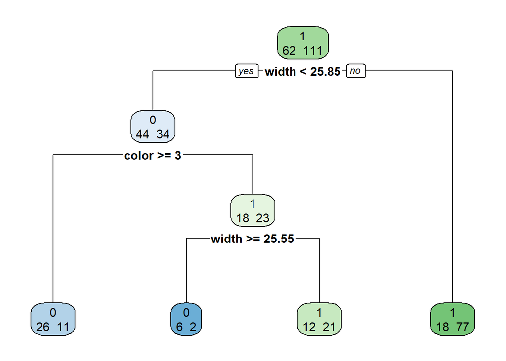

```r
pruned_fit <- prune(fit, cp=fit$cptable[4, "CP"])
rpart.plot(pruned_fit, extra=1, digits=4, box.palette="auto")
```

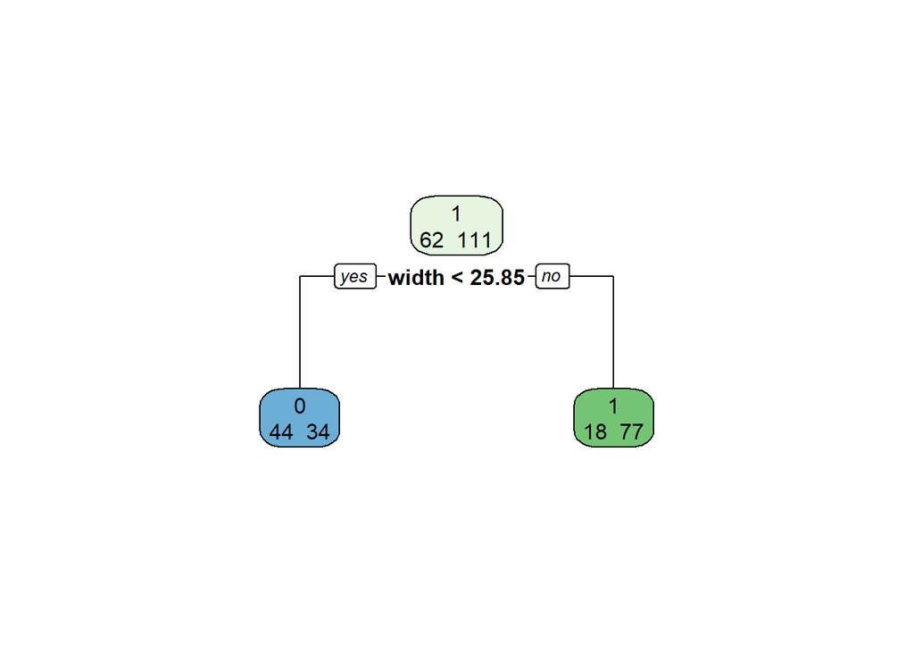

```r
pruned_tree <- prune(fit, cp=fit$cptable[2, "CP"])
rpart.plot(pruned_tree, extra=1, digits=4, box.palette="auto")
```

```r
y_hat_fit <- apply(predict(pruned_fit, crab), 1, which.max) - 1
y_hat_tree <- apply(predict(pruned_tree, crab), 1, which.max) - 1
```

```r
mean(crab$y == y_hat_fit)
```

```
## [1] 0.7514451
```

```r
mean(crab$y == y_hat_tree)
```

```
## [1] 0.699422
```

The crabs which were predicted to have satellites are the ones with width >= 25.85. The proportion of correct predictions for the simple tree is 0.7 which is less than the proportion of correct predictions for the more complex tree in figure 8.2 which is 0.75.

# LAB

LAB: Suppose you receive $n=15$ phone calls in a day, and you want to build a model to assess their average length. Your likelihood for each call length is $y_i∼Exponential(\lambda)$. Now, you have to choose the prior $\pi(\lambda)$. Please, tell which of these priors is adequate to describe the problem, and provide a short motivation for each of them:

$\pi(\lambda)=Beta(4,2);$

$\pi(\lambda)=Normal(1,2);$

$\pi(\lambda)=Gamma(4,2);$

Now, compute your posterior as $\pi(\lambda|y) \propto L(\lambda; y)\pi(\lambda)$ for the selected prior. If your first choice was correct, you will be able to compute it analytically.

The parameter of the exponential distribution is strictly positive and defined on the whole real line. This implies that a suitable prior distribution for $\lambda$ is given by the Gamma random variable.

$f_{y;\lambda} = \lambda^n e^{-\lambda \sum y_i}$

$f_{\lambda} = \frac{1}{\Gamma(\alpha)}\beta^{\alpha}\lambda^{\alpha-1}e^{-\beta \lambda}$

$f_{\lambda|y} \propto \lambda^n e^{-\lambda \sum y_i} \lambda^{\alpha - 1} e^{-\beta \lambda} = \lambda^{n + \alpha+1}e^{-\lambda(\sum y_i + \beta)}$

Which is the kernel of a Gamma distribution with parameters $\alpha + n$ and $\sum y_i + \beta$.

**Solution**

# ISLR - Chapter 7 - Exercises 7.9

## Exercise 1

It was mentioned in the chapter that a cubic regression spline with one knot at $\xi$ can be obtained using a basis of the form $x, x^2, x^3$, $(x − \xi)^3_+$, where $(x − \xi)^3_+ = (x − \xi)^3 \quad if \quad x > \xi$ and equals 0 otherwise. We will now show that a function of the form

$$f (x) = \beta_0 + \beta_1x + \beta_2x^2
+ \beta_3x^3 + \beta_4(x − \xi)^3$$

is indeed a cubic regression spline, regardless of the values of $\beta_0, \beta_1, \beta_2, \beta_3, \beta_4$.

1. Find a cubic polynomial
   $$f_1(x) = a_1 +
   b_1x + c_1x^2 + d_1x^3$$
   such that $f(x) = f_1(x)$ for all $x \leq \xi$. Express $a_1, b_1, c_1, d_1$ in terms of $\beta_0, \beta_1, \beta_2, \beta_3, \beta_4$.
2. Find a cubic polynomial
   $$f_2(x) = a_2 +
   b_2x + c_2x^2 + d_2x^3$$
   such that $f(x) = f_2(x)$ for all $x > \xi$. Express $a_2, b_2, c_2, d_2$ in terms of $\beta_0, \beta_1, \beta_2, \beta_3, \beta_4$. We have now established that f(x) is a piecewise polynomial.
3. Show that $f_1(\xi) = f_2(\xi)$. That is, $f(x)$ is continuous at $\xi$.
4. Show that $f^{'}_1(\xi) = f^{′}_2(\xi)$. That is, $f^′(x)$ is continuous at $\xi$.
5. Show that $f^{′′}_1(\xi) = f^{′′}_2(\xi)$. That is, $f^{′′}(x)$ is continuous at $\xi$. Therefore, $f(x)$ is indeed a cubic spline.

Hint: Parts (d) and (e) of this problem require knowledge of single-variable calculus. As a reminder, given a cubic polynomial
$$f_1(x) = a_1 + b_1x + c_1x^22 + d_1x^3,$$
the first derivative takes the form
$$f^′_1(x) = b_1 + 2c_1x + 3d_1x^2$$
and the second derivative takes the form
$$f^{′′}_1
(x) = 2c_1 + 6d_1x.$$

**Solution**

1. Given that for $x \leq \xi$ we have that $(x − \xi)^3_+ = 0$, then we can write $f(x)$ as:

$$f(x) = \beta_0 + \beta_1x + \beta_2x^2 + \beta_3x^3 + \beta_4 \cdot 0 =
\beta_0 + \beta_1x + \beta_2x^2 + \beta_3x^3$$

Then, the coefficients of $f_1(x)$ are:

- $a_1 = \beta_0$
- $b_1 = \beta_1$
- $c_1 = \beta_2$
- $d_1 = \beta_3$
2. Given that for $x > \xi$ we have that $(x − \xi)^3_+ = (x − \xi)^3$, then we can write $f(x)$ as:

$$f(x) = \beta_0 + \beta_1x + \beta_2x^2 + \beta_3x^3 + \beta_4(x − \xi)^3$$

If we expand the last term we get:

$$\beta_0 + \beta_1x + \beta_2x^2 + \beta_3x^3 + \beta_4(x^3 - 3 x^2 \xi +
3 \xi^2 x - \xi^3) = \\ = (\beta_0 - \beta_4\xi^3) + (\beta_1 +
3\beta_4\xi^2)x + (\beta_2 - 3\beta_4\xi)x^2 + (\beta_3 + \beta_4)x^3$$

Then, the coefficients of $f_2(x)$ are:

- $a_2 = \beta_0 - \beta_4\xi^3$
- $b_2 = \beta_1 + 3\beta_4\xi^2$
- $c_2 = \beta_2 - 3\beta_4\xi$
- $d_2 = \beta_3 + \beta_4$

$$f_1(\xi) = a_1 + b_1 \xi + c_1 \xi^2 + d_1 \xi^3 = \\ = \beta_0 +
\beta_1\xi + \beta_2\xi^2 + \beta_3\xi^3$$

$$f_2(\xi) = a_2 + b_2 \xi + c_2 \xi^2 + d_2 \xi^3 = \\ = (\beta_0 -
\beta_4\xi^3) + (\beta_1 + 3\beta_4\xi^2)\xi + (\beta_2 -
3\beta_4\xi)\xi^2 + (\beta_3 + \beta_4)\xi^3 = \\ = \beta_0 + \beta_1
\xi + \beta_2 \xi^2 + \beta_3 \xi^3 - \beta_4\xi^3 + \beta_4\xi^3 +
3\beta_4\xi^3 - 3\beta_4\xi^3 = \\ = \beta_0 + \beta_1 \xi + \beta_2
\xi^2 + \beta_3 \xi^3$$
$f_1(\xi) = f_2(\xi)$, $q. e. d.$

$$f^{'}_1(\xi) = b_1 + 2c_1\xi + 3d_1\xi^2 = \\ = \beta_1 +
2\beta_2\xi + 3\beta_3\xi^2$$

$$f^{'}_2(\xi) = b_2 + 2c_2\xi + 3d_2\xi^2 = \\ = (\beta_1 +
3\beta_4\xi^2) + 2(\beta_2 - 3\beta_4\xi)\xi + 3(\beta_3 + \beta_4)\xi^2
= \\ = \beta_1 + 2\beta_2\xi + 3\beta_3\xi^2 + 3\beta_4\xi^2 -
6\beta_4\xi^2 + 3\beta_4\xi^2 = \\ = \beta_1 + 2\beta_2\xi +
3\beta_3\xi^2$$

$f^{'}_1(\xi) = f^{'}_2(\xi)$, $q. e. d.$

$$f^{''}_1(\xi) = 2c_1 + 6d_1\xi = \\ = 2\beta_2 + 6\beta_3\xi$$
$$f^{''}_2(\xi) = 2c_2 + 6d_2\xi = \\ = 2(\beta_2 - 3\beta_4\xi) +
6(\beta_3 + \beta_4)\xi = \\ = 2\beta_2 + 6\beta_3\xi - 6\beta_4\xi +
6\beta_4\xi = \\ = 2\beta_2 + 6\beta_3\xi$$

$f^{''}_1(\xi) = f^{''}_2(\xi)$, $q. e. d.$

Therefore:

- Since $f(x)$ can be written as a linear combination of $f_1(x)$ and $f_2(x)$
- which are two cubic polynomials, defined for $x \leq \xi$ and for $x > \xi$,
- $f_1(x)$ and $f_2(x)$ are continuous and have continuous first and second derivatives,

then $f(x)$ is a cubic spline.

## Exercise 2

Suppose that a curve $\hat{g}$ is computed to smoothly fit a set of n points using the following formula:

$$\hat{g} = arg \min_g ( \sum_{i=1}^n (y_i
− g(x_i))^2 + \lambda \int [g^{(m)}(x)]^2 dx),$$
where $g^{(m)}$ represents the mth derivative of $g$ (and $g^{(0)} = g$). Provide example sketches of $\hat{g}$ in each of the following scenarios. (a) $\lambda = \inf, m = 0$. (b) $\lambda = \inf, m = 1$. (c) $\lambda = \inf, m = 2$. (d) $\lambda = \inf, m = 3$. (e) $\lambda = 0, m = 3$.

**Solution**

1. If $\lambda = \inf$ and $m = 0$, then we have that $\hat{g} = arg \min_g (\sum_{i=1}^n (y_i − g(x_i))^2)$, which reduce the value of the function $g$, then the result will be a constant function equal to zero.
2. If $\lambda = \inf$ and $m = 1$, then we have that $\hat{g} = arg \min_g (\sum_{i=1}^n (y_i − g(x_i))^2 + \lambda \int [g^{(1)}(x)]^2 dx)$, which is the least squares fit with a penalty on the first derivative. The penalty term is so high that the fit is a straight line.
3. If $\lambda = \inf$ and $m = 2$, then we have that $\hat{g} = arg \min_g (\sum_{i=1}^n (y_i − g(x_i))^2 + \lambda \int [g^{(2)}(x)]^2 dx)$, which is the least squares fit with a penalty on the second derivative. The penalty term is so high that the fit is a parabolic line.
4. If $\lambda = \inf$ and $m = 3$, then we have that $\hat{g} = arg \min_g (\sum_{i=1}^n (y_i − g(x_i))^2 + \lambda \int [g^{(3)}(x)]^2 dx)$, which is the least squares fit with a penalty on the third derivative. The penalty term is so high that the fit is a cubic line.
5. If $\lambda = 0$ and $m = 3$, then we have that $\hat{g} = arg \min_g ( \sum_{i=1}^n (y_i − g(x_i))^2 + \lambda \int [g^{(3)}(x)]^2 dx)$, which is the least squares fit with no penalty because the factor $\lambda$ is zero.

## Exercise 3

Suppose we fit a curve with basis functions $b_1(X) = X$, $b_2(X) = (X − 1)^2I(X \geq 1)$. (Note that $I(X \geq 1)$ equals 1 for $X \geq 1$ and 0 otherwise.) We fit the linear regression model
$$Y = \beta_0 +
\beta_1b_1(X) + \beta_2b_2(X) + e,$$
and obtain coefficient estimates $\hat{\beta}_0 = 1$, $\hat{\beta}_1 = 1$, $\hat{\beta}_2 = −2$. Sketch the estimated curve between $X = −2$ and $X = 2$. Note the intercepts, slopes, and other relevant information.

**Solution**

```r
Identity <- function(x) {
  if (x >= 1) {
    return(1)
  } else {
    return(0)
  }
}
```

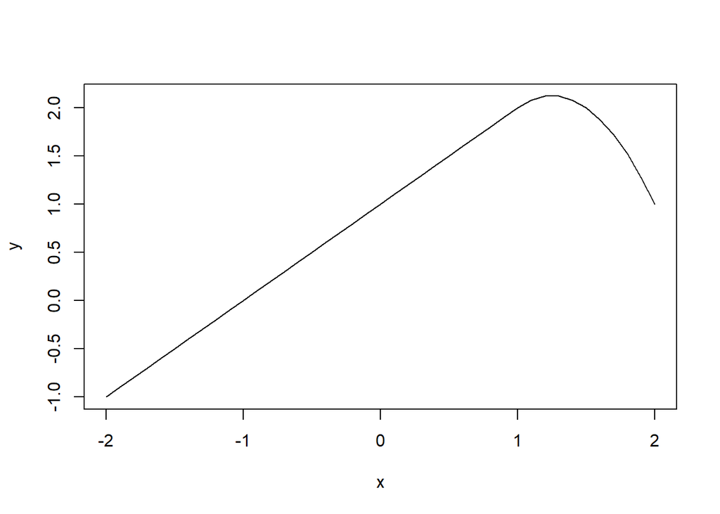

```r
x <- seq(-2, 2, 0.1)

y <- 1 + x - 2 * (x - 1)^2 * sapply(x, Identity)

plot(x, y, type = "l")
```

## Exercise 4

Suppose we fit a curve with basis functions $b_1(X) = I(0 \leq X \leq 2) − (X − 1)I(1 \leq X \leq 2)$, $b_2(X) = (X − 3)I(3 \leq X \leq 4) + I(4 < X \leq 5)$. We fit the linear regression model
$$Y = \beta_0 + \beta_1b_1(X) +
\beta_2b_2(X) + e,$$
and obtain coefficient estimates $\hat{\beta}_0 = 1$, $\hat{\beta}_1 = 1$, $\hat{\beta}_2 = 3$. Sketch the estimated curve between $X = −2$ and $X = 2$. Note the intercepts, slopes, and other relevant information.

**Solution**

```r
Identity_range <- function(x, l, u) {
  if (x <= u && x >= l) {
    return(1)
  } else {
    return(0)
  }
}

b1 <- function(x) {
  return(Identity_range(x, 0, 2) - (x - 1) * Identity_range(x, 1, 2))
}

b2 <- function(x) {
  return((x - 3) * Identity_range(x, 3, 4) + Identity_range(x, 4, 5))
}
```

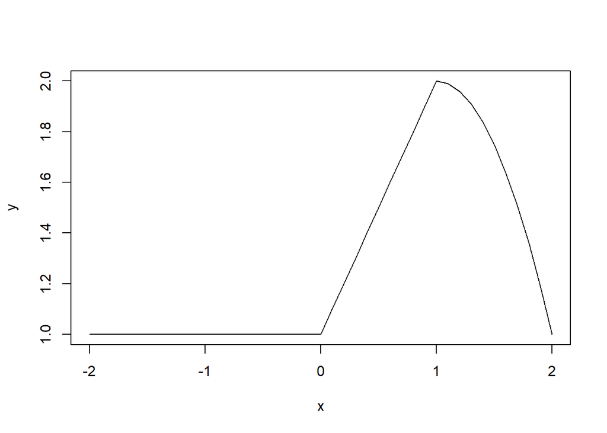

```r
x <- seq(-2, 2, 0.1)

y <- 1 + x * sapply(x, b1) + 3 * sapply(x, b2)

plot(x, y, type = "l")
```

## Exercise 5

Consider two curves, $\hat{g}_1$ and $\hat{g}_2$, defined by
$$\hat{g}_1 = arg \min_g ( \sum_{i=1}^n (y_i −
g(x_i))^2 + \lambda \int [g^{(3)}(x)]^2 dx),$$

$$\hat{g}_2 = arg \min_g ( \sum_{i=1}^n
(y_i − g(x_i))^2 + \lambda \int [g^{(4)}(x)]^2 dx),$$

where $g^{(m)}$ represents the mth derivative of $g$.

1. As $\lambda \to \inf$, will $\hat{g}_1$ or $\hat{g}_2$ have the smaller training RSS?
2. As $\lambda \to \inf$, will $\hat{g}_1$ or $\hat{g}_2$ have the smaller test RSS?
3. For $\lambda \to 0$, will $\hat{g}_1$ or $\hat{g}_2$ have the smaller training and test RSS?

**Solution**

1. In the limit of $\lambda \to \inf$ the penalty term will dominate the RSS. For this reason the resulting function will be the most smooth possible. This means that both the functions will have the same training RSS. But the function $\hat{g}_2$ will have the greater training RSS because uses a greater derivative order.
2. As before, in the limit of $\lambda \to \inf$ the penalty term will dominate the RSS. For this reason the resulting function will be the most smooth possible. This means that both the functions will have the same test RSS. But the function $\hat{g}_2$ will have the greater test RSS because uses a greater derivative order.
3. In the limit of $\lambda \to 0$ the penalty term will be negligible. For this reason the resulting function will be the most flexible possible. This means that both the functions will have the same training and test RSS.

## Exercise 6

In this exercise, you will further analyze the Wage data set considered throughout this chapter.

1. Perform polynomial regression to predict wage using age. Use cross-validation to select the optimal degree d for the polynomial. What degree was chosen, and how does this compare to the results of hypothesis testing using ANOVA? Make a plot of the resulting polynomial fit to the data.
2. Fit a step function to predict wage using age, and perform cross-validation to choose the optimal number of cuts. Make a plot of the fit obtained.

**Solution**

```r
library(ISLR)
library(modelr)
cv  <- crossv_kfold(Wage, k = 10)

data <- Wage
models <- vector("list", 10)
RMSE <- rep(NA, 10)
R2 <- rep(NA, 10)
```

```r
results.df <- data.frame("degree"=rep(NA, 5), "RMSE"=rep(NA, 5), "R2"=rep(NA, 5))

for (d in 1:5){
  for (i in 1:10) {
    model <- lm(wage ~ poly(age, d), data = cv$train[[i]])

    y_hat <- predict(model, cv$test[[i]])
    RMSE[i] <- sqrt(mean((y_hat - data$wage[cv$test[[i]][2]$idx])^2))

    R2[i] <- summary(model)$adj.r.squared

  }

  models[[d]] <- model
  results.df[d, ] <- list("degree"=d, "RMSE"=mean(RMSE), "R2"=mean(R2))
}

results.df
```

```
##   degree     RMSE         R2
## 1      1 40.90612 0.03799142
## 2      2 39.97197 0.08148064
## 3      3 39.91855 0.08418779
## 4      4 39.89666 0.08502377
## 5      5 39.89726 0.08494429
```

```r
anova(models[[1]], models[[2]], models[[3]], models[[4]], models[[5]])
```

```
## Analysis of Variance Table
##
## Model 1: wage ~ poly(age, d)
## Model 2: wage ~ poly(age, d)
## Model 3: wage ~ poly(age, d)
## Model 4: wage ~ poly(age, d)
## Model 5: wage ~ poly(age, d)
##   Res.Df     RSS Df Sum of Sq        F  Pr(>F)
## 1   2698 4467316
## 2   2697 4265947  1    201369 127.7795 < 2e-16 ***
## 3   2696 4252174  1     13773   8.7399 0.00314 **
## 4   2695 4246907  1      5267   3.3422 0.06763 .
## 5   2694 4245502  1      1405   0.8915 0.34515
## ---
## Signif. codes:  0 '***' 0.001 '**' 0.01 '*' 0.05 '.' 0.1 ' ' 1
```

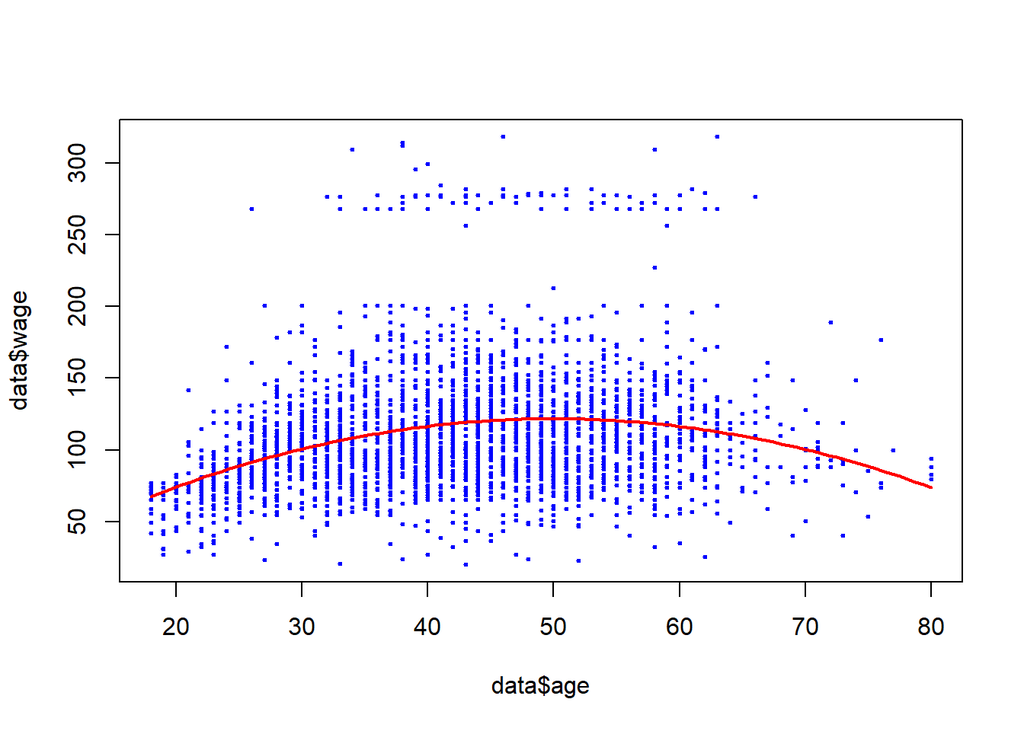

```r
x <- seq(18, 80, length.out=100)
poly2 <- lm(wage ~ poly(age, 2), data = Wage)
y_hat <- predict(poly2, data.frame(age = x))

plot(data$age, data$wage, col = "blue", pch = 20, cex = 0.5)
lines(x, y_hat, col = "red", lwd = 2)
```

```r
results.df <- data.frame("degree"=rep(NA, 10), "RMSE"=rep(NA, 10), "R2"=rep(NA, 10))

for (d in 3:10){
  for (i in 1:10) {
    model <- lm(wage ~ cut(age, seq(1, 80, length.out=d)), data = cv$train[[i]])

    y_hat <- predict(model, cv$test[[i]])
    RMSE[i] <- sqrt(mean((y_hat - data$wage[cv$test[[i]][2]$idx])^2))

    R2[i] <- summary(model)$adj.r.squared

  }

  models[[d]] <- model
  results.df[d, ] <- list("degree"=d, "RMSE"=mean(RMSE), "R2"=mean(R2))
}

results.df[c(-1, -2), ]
```

```
##    degree     RMSE         R2
## 3       3 41.13294 0.02689548
## 4       4 40.41172 0.06150623
## 5       5 40.81661 0.04197746
## 6       6 40.35471 0.06370002
## 7       7 40.24668 0.06972045
## 8       8 40.01123 0.07928845
## 9       9 40.24172 0.06878170
## 10     10 40.13757 0.07494057
```

The best result is obtained with 8 cuts. This results are really similar to the previous polynomial models. The plot of the fit obtained is the following:

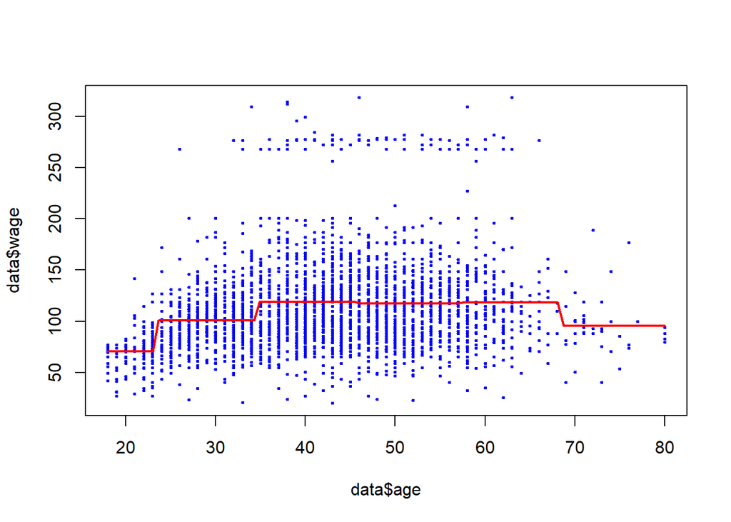

```r
x <- seq(18, 80, length.out=100)
cut8 <- lm(wage ~ cut(age, seq(1, 80, length.out=8)), data = Wage)
y_hat <- predict(cut8, data.frame(age = x))

plot(data$age, data$wage, col = "blue", pch = 20, cex = 0.5)
lines(x, y_hat, col = "red", lwd = 2)
```

## Exercise 7

The Wage data set contains a number of other features not explored in this chapter, such as marital status (maritl), job class (jobclass), and others. Explore the relationships between some of these other predictors and wage, and use non-linear fitting techniques in order to fit flexible models to the data. Create plots of the results obtained, and write a summary of your findings.

**Solution**

```r
library(ISLR)

summary(Wage)
```

```
##       year           age                     maritl           race
##  Min.   :2003   Min.   :18.00   1. Never Married: 648   1. White:2480
##  1st Qu.:2004   1st Qu.:33.75   2. Married      :2074   2. Black: 293
##  Median :2006   Median :42.00   3. Widowed      :  19   3. Asian: 190
##  Mean   :2006   Mean   :42.41   4. Divorced     : 204   4. Other:  37
##  3rd Qu.:2008   3rd Qu.:51.00   5. Separated    :  55
##  Max.   :2009   Max.   :80.00
##
##               education                     region               jobclass
##  1. < HS Grad      :268   2. Middle Atlantic   :3000   1. Industrial :1544
##  2. HS Grad        :971   1. New England       :   0   2. Information:1456
##  3. Some College   :650   3. East North Central:   0
##  4. College Grad   :685   4. West North Central:   0
##  5. Advanced Degree:426   5. South Atlantic    :   0
##                           6. East South Central:   0
##                           (Other)              :   0
##             health      health_ins      logwage           wage
##  1. <=Good     : 858   1. Yes:2083   Min.   :3.000   Min.   : 20.09
##  2. >=Very Good:2142   2. No : 917   1st Qu.:4.447   1st Qu.: 85.38
##                                      Median :4.653   Median :104.92
##                                      Mean   :4.654   Mean   :111.70
##                                      3rd Qu.:4.857   3rd Qu.:128.68
##                                      Max.   :5.763   Max.   :318.34
##
```

```r
data <- Wage[, -c(6, 10)]

complete <- lm(wage ~ ., data = data)
summary(complete)
```

```
##
## Call:
## lm(formula = wage ~ ., data = data)
##
## Residuals:
##     Min      1Q  Median      3Q     Max
## -100.33  -18.70   -3.26   13.29  212.79
##
## Coefficients:
##                               Estimate Std. Error t value Pr(>|t|)
## (Intercept)                 -2.423e+03  6.165e+02  -3.931 8.67e-05 ***
## year                         1.241e+00  3.074e-01   4.037 5.54e-05 ***
## age                          2.707e-01  6.223e-02   4.350 1.41e-05 ***
## maritl2. Married             1.718e+01  1.720e+00   9.985  < 2e-16 ***
## maritl3. Widowed             2.052e+00  8.005e+00   0.256  0.79774
## maritl4. Divorced            3.967e+00  2.887e+00   1.374  0.16951
## maritl5. Separated           1.153e+01  4.844e+00   2.380  0.01736 *
## race2. Black                -5.096e+00  2.146e+00  -2.375  0.01760 *
## race3. Asian                -2.814e+00  2.603e+00  -1.081  0.27978
## race4. Other                -6.059e+00  5.666e+00  -1.069  0.28505
## education2. HS Grad          7.759e+00  2.369e+00   3.275  0.00107 **
## education3. Some College     1.834e+01  2.520e+00   7.278 4.32e-13 ***
## education4. College Grad     3.124e+01  2.548e+00  12.259  < 2e-16 ***
## education5. Advanced Degree  5.395e+01  2.811e+00  19.190  < 2e-16 ***
## jobclass2. Information       3.571e+00  1.324e+00   2.697  0.00704 **
## health2. >=Very Good         6.515e+00  1.421e+00   4.585 4.72e-06 ***
## health_ins2. No             -1.751e+01  1.403e+00 -12.479  < 2e-16 ***
## ---
## Signif. codes:  0 '***' 0.001 '**' 0.01 '*' 0.05 '.' 0.1 ' ' 1
##
## Residual standard error: 34 on 2983 degrees of freedom
## Multiple R-squared:  0.3396, Adjusted R-squared:  0.3361
## F-statistic: 95.89 on 16 and 2983 DF,  p-value: < 2.2e-16
```

```r
poly <- lm(wage ~ poly(age, 2) + poly(year, 3) + maritl + race + education + jobclass + health_ins, data = data)

summary(poly)
```

```
##
## Call:
## lm(formula = wage ~ poly(age, 2) + poly(year, 3) + maritl + race +
##     education + jobclass + health_ins, data = data)
##
## Residuals:
##      Min       1Q   Median       3Q      Max
## -100.323  -18.729   -3.132   13.743  210.615
##
## Coefficients:
##                              Estimate Std. Error t value Pr(>|t|)
## (Intercept)                   84.4940     2.6893  31.419  < 2e-16 ***
## poly(age, 2)1                182.6959    39.1080   4.672 3.12e-06 ***
## poly(age, 2)2               -243.2311    36.1375  -6.731 2.02e-11 ***
## poly(year, 3)1               141.4762    33.9822   4.163 3.23e-05 ***
## poly(year, 3)2               -26.7790    33.9983  -0.788  0.43096
## poly(year, 3)3                16.0165    33.9234   0.472  0.63686
## maritl2. Married              14.0562     1.7934   7.838 6.33e-15 ***
## maritl3. Widowed               0.9325     7.9791   0.117  0.90697
## maritl4. Divorced              0.2445     2.9275   0.084  0.93345
## maritl5. Separated             7.7703     4.8640   1.598  0.11026
## race2. Black                  -4.8028     2.1390  -2.245  0.02482 *
## race3. Asian                  -2.9327     2.5941  -1.131  0.25834
## race4. Other                  -6.3412     5.6436  -1.124  0.26127
## education2. HS Grad            7.6835     2.3608   3.255  0.00115 **
## education3. Some College      18.5018     2.5092   7.374 2.14e-13 ***
## education4. College Grad      31.5598     2.5298  12.475  < 2e-16 ***
## education5. Advanced Degree   54.4881     2.7859  19.558  < 2e-16 ***
## jobclass2. Information         3.6034     1.3196   2.731  0.00636 **
## health_ins2. No              -16.7759     1.4051 -11.939  < 2e-16 ***
## ---
## Signif. codes:  0 '***' 0.001 '**' 0.01 '*' 0.05 '.' 0.1 ' ' 1
##
## Residual standard error: 33.87 on 2981 degrees of freedom
## Multiple R-squared:  0.3452, Adjusted R-squared:  0.3413
## F-statistic: 87.32 on 18 and 2981 DF,  p-value: < 2.2e-16
```

```r
poly2 <- lm(wage ~ poly(age, 2) + year + maritl + race + education + jobclass + health_ins, data = data)

summary(poly2)
```

```
##
## Call:
## lm(formula = wage ~ poly(age, 2) + year + maritl + race + education +
##     jobclass + health_ins, data = data)
##
## Residuals:
##      Min       1Q   Median       3Q      Max
## -101.267  -18.679   -3.029   13.927  209.640
##
## Coefficients:
##                               Estimate Std. Error t value Pr(>|t|)
## (Intercept)                 -2475.4368   614.1926  -4.030 5.71e-05 ***
## poly(age, 2)1                 181.7382    39.0795   4.650 3.46e-06 ***
## poly(age, 2)2                -244.3837    36.1082  -6.768 1.56e-11 ***
## year                            1.2762     0.3062   4.168 3.16e-05 ***
## maritl2. Married               14.0700     1.7922   7.851 5.72e-15 ***
## maritl3. Widowed                1.1382     7.9743   0.143  0.88651
## maritl4. Divorced               0.2567     2.9266   0.088  0.93011
## maritl5. Separated              7.7634     4.8630   1.596  0.11050
## race2. Black                   -4.7446     2.1377  -2.220  0.02653 *
## race3. Asian                   -3.0080     2.5919  -1.161  0.24593
## race4. Other                   -6.3971     5.6418  -1.134  0.25694
## education2. HS Grad             7.7429     2.3595   3.282  0.00104 **
## education3. Some College       18.5838     2.5071   7.412 1.61e-13 ***
## education4. College Grad       31.6005     2.5289  12.496  < 2e-16 ***
## education5. Advanced Degree    54.5216     2.7852  19.576  < 2e-16 ***
## jobclass2. Information          3.6481     1.3183   2.767  0.00569 **
## health_ins2. No               -16.7882     1.4047 -11.951  < 2e-16 ***
## ---
## Signif. codes:  0 '***' 0.001 '**' 0.01 '*' 0.05 '.' 0.1 ' ' 1
##
## Residual standard error: 33.86 on 2983 degrees of freedom
## Multiple R-squared:  0.345,  Adjusted R-squared:  0.3415
## F-statistic: 98.22 on 16 and 2983 DF,  p-value: < 2.2e-16
```

```r
anova(poly2)
```

```
## Analysis of Variance Table
##
## Response: wage
##                Df  Sum Sq Mean Sq F value    Pr(>F)
## poly(age, 2)    2  428656  214328 186.926 < 2.2e-16 ***
## year            1   20823   20823  18.160 2.093e-05 ***
## maritl          4  135322   33830  29.505 < 2.2e-16 ***
## race            3   34572   11524  10.051 1.376e-06 ***
## education       4 1001909  250477 218.454 < 2.2e-16 ***
## jobclass        1   16746   16746  14.605 0.0001352 ***
## health_ins      1  163775  163775 142.836 < 2.2e-16 ***
## Residuals    2983 3420283    1147
## ---
## Signif. codes:  0 '***' 0.001 '**' 0.01 '*' 0.05 '.' 0.1 ' ' 1
```

We can notice that the remaining variables are statistically significant but the R-squared value is increased only by 0.01 (roughly). We can try to use the step function instead of the polynomial fit.

```r
cutted <- lm(wage ~ cut(age, seq(1, 80, length.out=8)) + year + maritl + race + education + jobclass + health_ins, data = data)

summary(cutted)
```

```
##
## Call:
## lm(formula = wage ~ cut(age, seq(1, 80, length.out = 8)) + year +
##     maritl + race + education + jobclass + health_ins, data = data)
##
## Residuals:
##      Min       1Q   Median       3Q      Max
## -102.567  -18.991   -3.225   13.525  207.421
##
## Coefficients:
##                                                   Estimate Std. Error t value
## (Intercept)                                     -2604.3153   614.5489  -4.238
## cut(age, seq(1, 80, length.out = 8))(23.6,34.9]     8.7958     3.2584   2.699
## cut(age, seq(1, 80, length.out = 8))(34.9,46.1]    20.2229     3.3617   6.016
## cut(age, seq(1, 80, length.out = 8))(46.1,57.4]    17.4027     3.4493   5.045
## cut(age, seq(1, 80, length.out = 8))(57.4,68.7]    18.0612     3.8795   4.655
## cut(age, seq(1, 80, length.out = 8))(68.7,80]       2.6803     6.2824   0.427
## year                                                1.3325     0.3064   4.349
## maritl2. Married                                   14.4255     1.7666   8.166
## maritl3. Widowed                                    1.1625     7.9756   0.146
## maritl4. Divorced                                   0.6029     2.9055   0.208
## maritl5. Separated                                  8.1551     4.8517   1.681
## race2. Black                                       -4.7833     2.1365  -2.239
## race3. Asian                                       -2.9876     2.5923  -1.153
## race4. Other                                       -6.1095     5.6405  -1.083
## education2. HS Grad                                 7.9340     2.3600   3.362
## education3. Some College                           18.8240     2.5077   7.506
## education4. College Grad                           31.8508     2.5311  12.584
## education5. Advanced Degree                        54.8338     2.7836  19.699
## jobclass2. Information                              3.7267     1.3168   2.830
## health_ins2. No                                   -16.8082     1.4075 -11.942
##                                                 Pr(>|t|)
## (Intercept)                                     2.33e-05 ***
## cut(age, seq(1, 80, length.out = 8))(23.6,34.9] 0.006985 **
## cut(age, seq(1, 80, length.out = 8))(34.9,46.1] 2.01e-09 ***
## cut(age, seq(1, 80, length.out = 8))(46.1,57.4] 4.80e-07 ***
## cut(age, seq(1, 80, length.out = 8))(57.4,68.7] 3.37e-06 ***
## cut(age, seq(1, 80, length.out = 8))(68.7,80]   0.669674
## year                                            1.41e-05 ***
## maritl2. Married                                4.66e-16 ***
## maritl3. Widowed                                0.884123
## maritl4. Divorced                               0.835623
## maritl5. Separated                              0.092896 .
## race2. Black                                    0.025244 *
## race3. Asian                                    0.249205
## race4. Other                                    0.278827
## education2. HS Grad                             0.000784 ***
## education3. Some College                        7.98e-14 ***
## education4. College Grad                         < 2e-16 ***
## education5. Advanced Degree                      < 2e-16 ***
## jobclass2. Information                          0.004685 **
## health_ins2. No                                  < 2e-16 ***
## ---
## Signif. codes:  0 '***' 0.001 '**' 0.01 '*' 0.05 '.' 0.1 ' ' 1
##
## Residual standard error: 33.83 on 2980 degrees of freedom
## Multiple R-squared:  0.3469, Adjusted R-squared:  0.3427
## F-statistic:  83.3 on 19 and 2980 DF,  p-value: < 2.2e-16
```

In this case the results are slightly better than the previous ones. As last try we can use the splines on the variable age.

```r
library(mgcv)
smoothed <- gam(wage ~ s(age) + year + maritl + race + education + jobclass + health_ins, data = data)

summary(smoothed)
```

```
##
## Family: gaussian
## Link function: identity
##
## Formula:
## wage ~ s(age) + year + maritl + race + education + jobclass +
##     health_ins
##
## Parametric coefficients:
##                               Estimate Std. Error t value Pr(>|t|)
## (Intercept)                 -2559.5931   614.6692  -4.164 3.21e-05 ***
## year                            1.3182     0.3064   4.302 1.75e-05 ***
## maritl2. Married               13.9269     1.8122   7.685 2.06e-14 ***
## maritl3. Widowed                0.7398     7.9818   0.093 0.926164
## maritl4. Divorced               0.1296     2.9347   0.044 0.964769
## maritl5. Separated              7.8961     4.8628   1.624 0.104528
## race2. Black                   -4.8366     2.1380  -2.262 0.023759 *
## race3. Asian                   -2.9426     2.5929  -1.135 0.256527
## race4. Other                   -6.0222     5.6414  -1.068 0.285831
## education2. HS Grad             7.9225     2.3591   3.358 0.000794 ***
## education3. Some College       18.8579     2.5082   7.519 7.28e-14 ***
## education4. College Grad       31.8874     2.5296  12.606  < 2e-16 ***
## education5. Advanced Degree    54.6855     2.7847  19.638  < 2e-16 ***
## jobclass2. Information          3.6081     1.3178   2.738 0.006220 **
## health_ins2. No               -16.8312     1.4050 -11.980  < 2e-16 ***
## ---
## Signif. codes:  0 '***' 0.001 '**' 0.01 '*' 0.05 '.' 0.1 ' ' 1
##
## Approximate significance of smooth terms:
##          edf Ref.df     F p-value
## s(age) 4.655  5.714 11.13  <2e-16 ***
## ---
## Signif. codes:  0 '***' 0.001 '**' 0.01 '*' 0.05 '.' 0.1 ' ' 1
##
## R-sq.(adj) =  0.343   Deviance explained = 34.7%
## GCV = 1152.2  Scale est. = 1144.7    n = 3000
```

The results are similar to the previous ones. Then the best model is the one obtained with the step function even if the difference is really small. The plot of the fit obtained is the following:

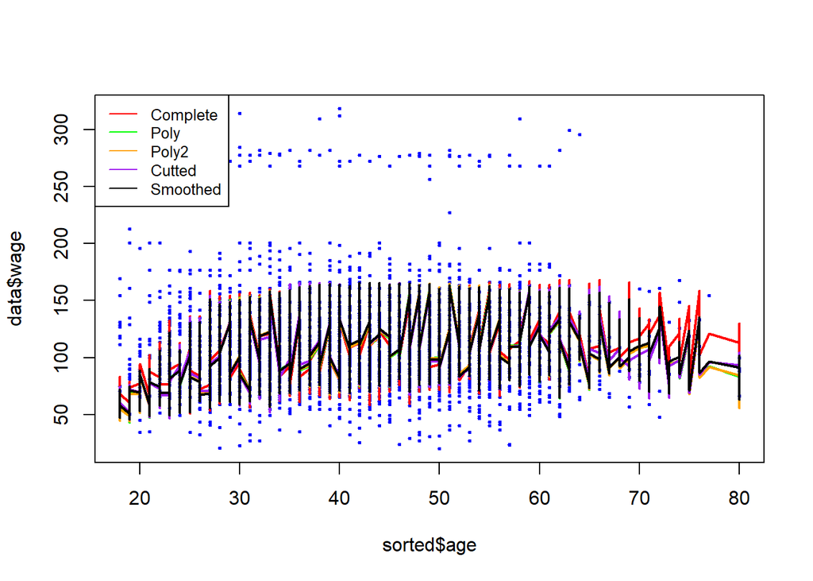

```r
sorted <- data[order(data$age), ]
y_hat_complete <- predict(complete, data.frame(sorted))
y_hat_poly     <- predict(poly    , data.frame(sorted))
y_hat_poly2    <- predict(poly2   , data.frame(sorted))
y_hat_cutted   <- predict(cutted  , data.frame(sorted))
y_hat_smoothed <- predict(smoothed, data.frame(sorted))

plot (sorted$age, data$wage     , col = "blue"  , pch = 20, cex = 0.5)
lines(sorted$age, y_hat_complete, col = "red"   , lwd = 2)
lines(sorted$age, y_hat_poly    , col = "green" , lwd = 2)
lines(sorted$age, y_hat_poly2   , col = "orange", lwd = 2)
lines(sorted$age, y_hat_cutted  , col = "purple", lwd = 2)
lines(sorted$age, y_hat_smoothed, col = "black" , lwd = 2)
legend("topleft", legend = c("Complete", "Poly", "Poly2", "Cutted", "Smoothed"), col = c("red", "green", "orange", "purple", "black"), lty = 1, cex = 0.8)
```

```r
unloadNamespace("mgcv")
```

From the plot we can notice that the models are really similar but all of them are not smoothed at all.